© Bản quyền thuộc về Quantopian Inc.  
© Bản quyền sửa đổi thuộc về AI Cafe¹  
Giấy phép [Creative Commons Attribution 4.0](https://creativecommons.org/licenses/by/4.0/legalcode).  
[Khuyến cáo](https://aicafe.one/khuyen-cao/)

# Sự không chắc chắn của các ước lượng tham số

By Evgenia "Jenny" Nitishinskaya and Delaney Granizo-Mackenzie. Algorithms by David Edwards.

Edited by AI Cafe¹

## Tham Số

Một tham số là giá trị mà một mô hình sử dụng để hạn chế các dự đoán của nó. Thông thường, một tham số là một đại lượng giúp mô tả một tập dữ liệu hoặc một phân phối. Ví dụ, trung bình của một phân phối chuẩn là một tham số; thực tế, chúng ta nói rằng một phân phối chuẩn được *tham số hóa* bởi trung bình và phương sai của nó. Nếu chúng ta lấy trung bình của một tập hợp các mẫu được rút ra từ phân phối chuẩn, chúng ta sẽ có được một ước lượng của trung bình của phân phối. Tương tự như vậy, trung bình của một tập hợp các quan sát là một ước lượng của tham số của phân phối cơ sở (mà thường được giả định là chuẩn). Các tham số khác bao gồm trung vị, hệ số tương quan với một chuỗi khác, độ lệch chuẩn, và mọi phép đo khác của một tập dữ liệu.

## Bạn Không Bao Giờ Biết, Bạn Chỉ Ước Lượng

Khi tính trung bình của một tập dữ liệu, bạn không biết chính xác giá trị trung bình. Bạn đã ước lượng giá trị trung bình tốt nhất có thể từ dữ liệu bạn có. Sự ước lượng này có thể không chính xác. Điều này đúng với bất kỳ tham số nào mà bạn ước lượng. Để thực sự hiểu điều gì đang xảy ra, bạn cần xác định độ chính xác của ước lượng của mình bằng cách xem xét tính ổn định/độ lệch chuẩn/ khoảng tin cậy của nó.

## Sự không ổn định của các ước lượng

Mỗi khi chúng ta xem xét một tập hợp các quan sát, việc tính toán một tham số chỉ có thể là một ước lượng. Nó sẽ thay đổi khi chúng ta thực hiện nhiều phép đo hơn hoặc khi thời gian trôi qua và chúng ta có được những quan sát mới. Chúng ta có thể định lượng sự không chắc chắn trong ước lượng của mình bằng cách xem xét cách mà tham số thay đổi khi chúng ta xem xét các tập con khác nhau của dữ liệu. Ví dụ, độ lệch chuẩn mô tả mức độ khác nhau giữa trung bình của một tập hợp và trung bình của từng quan sát, nghĩa là, so với từng quan sát một. Trong các ứng dụng tài chính, dữ liệu thường xuất hiện dưới dạng chuỗi thời gian. Trong trường hợp này, chúng ta có thể ước lượng một tham số tại các thời điểm khác nhau; chẳng hạn, trong 30 ngày trước đó. Bằng cách xem xét mức độ dao động của ước lượng di động này khi chúng ta thay đổi cửa sổ thời gian của mình, chúng ta có thể tính toán sự không ổn định của tham số ước lượng.

```python
# We'll be doing some examples, so let's import the libraries we'll need
import numpy as np
import matplotlib.pyplot as plt
import pandas as pd
```

## Ví dụ: trung bình và độ lệch chuẩn

Trước tiên, hãy cùng xem một số mẫu từ một phân phối chuẩn. Chúng ta biết rằng trung bình của phân phối là 0 và độ lệch chuẩn là 1; nhưng nếu chúng ta đo các tham số từ những quan sát của mình, chúng ta chỉ có thể nhận được khoảng 0 và khoảng 1. Chúng ta có thể thấy cách mà những ước lượng này thay đổi khi chúng ta lấy nhiều mẫu hơn:

```
-0.26951611032632805
0.027109073490359778
-0.020616059111720507
-0.038643973513210604
```

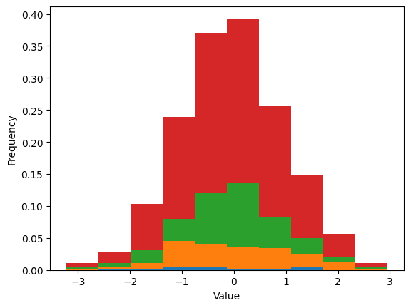

```python
# Set a seed so we can play with the data without generating new random numbers every time
np.random.seed(123)

normal = np.random.randn(500)
print(np.mean(normal[:10]))
print(np.mean(normal[:100]))
print(np.mean(normal[:250]))
print(np.mean(normal))

# Plot a stacked histogram of the data
plt.hist([normal[:10], normal[10:100], normal[100:250], normal], density=1, histtype='bar', stacked=True);
plt.ylabel('Frequency')
plt.xlabel('Value');
```

```python
print(np.std(normal[:10]))
print(np.std(normal[:100]))
print(np.std(normal[:250]))
print(np.std(normal))
```

```
1.236304801499023
1.128240470477961
1.0174604368340197
1.0032028561568238
```

Lưu ý rằng, mặc dù xác suất gần hơn đến 0 và 1 cho trung bình và độ lệch chuẩn, tương ứng, tăng lên với số lượng mẫu, chúng ta không phải lúc nào cũng có được ước lượng tốt hơn bằng cách lấy nhiều điểm dữ liệu hơn. Bất kể kỳ vọng của chúng ta là gì, chúng ta luôn có thể nhận được một kết quả khác, và mục tiêu của chúng ta thường là tính toán xác suất mà kết quả khác biệt đáng kể so với kỳ vọng.

## Ví dụ: Phân phối cơ sở không chuẩn tắc

Điều gì sẽ xảy ra nếu dữ liệu cơ sở không theo phân phối chuẩn? Trung bình sẽ rất dễ gây hiểu lầm. Vì lý do này, việc kiểm tra tính chuẩn của dữ liệu rất quan trọng. Chúng ta sẽ sử dụng kiểm định Jarque-Bera làm ví dụ.

```
mean: 0.009847581282146528
standard deviation: 5.060708740105227
```

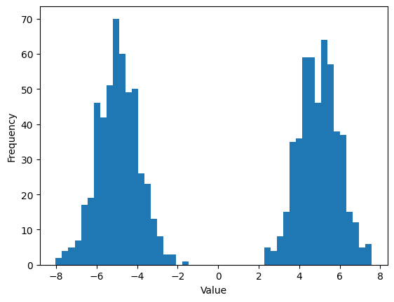

```python
#Generate some data from a bi-modal distribution
def bimodal(n):
    X = np.zeros((n))
    for i in range(n):
        if np.random.binomial(1, 0.5) == 0:
            X[i] = np.random.normal(-5, 1)
        else:
            X[i] =  np.random.normal(5, 1)
    return X

X = bimodal(1000)

#Let's see how it looks
plt.hist(X, bins=50)
plt.ylabel('Frequency')
plt.xlabel('Value')
print('mean:', np.mean(X))
print('standard deviation:', np.std(X))
```

Quả thật, giá trị trung bình không cung cấp thông tin về những gì đang diễn ra trong dữ liệu. Chúng ta đã gộp tất cả dữ liệu của mình thành một ước lượng duy nhất, và đã mất đi rất nhiều thông tin trong quá trình đó. Đây là hình dạng của phân phối nếu giả thuyết của chúng ta rằng nó tuân theo phân phối chuẩn là đúng.

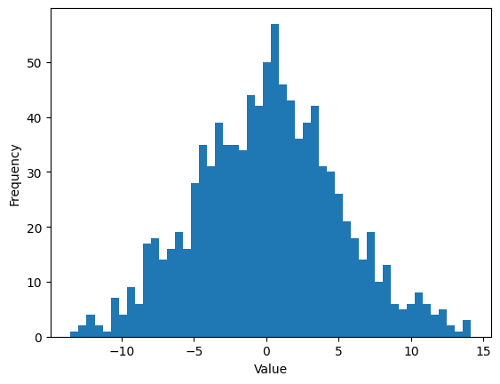

```python
mu = np.mean(X)
sigma = np.std(X)

N = np.random.normal(mu, sigma, 1000)

plt.hist(N, bins=50)
plt.ylabel('Frequency')
plt.xlabel('Value');
```

Chúng ta sẽ kiểm thử dữ liệu của mình bằng cách sử dụng kiểm định Jarque-Bera để xem nó có phân phối chuẩn hay không. Giá trị p-value ý nghĩa cho thấy dữ liệu không phân phối chuẩn.

```python
from statsmodels.stats.stattools import jarque_bera

jarque_bera(X)
```

```
(np.float64(142.12550136207705),
 np.float64(1.3735343038981241e-31),
 np.float64(-0.007644415681800414),
 np.float64(1.1531707484649847))
```

Giá trị p-value < 0.05 và chúng ta nói rằng X không chuẩn. Điều này giúp chúng ta tránh việc vô tình đưa ra những dự đoán sai lệch.

## Ví dụ: Tỷ lệ Sharpe

Một thống kê thường được sử dụng để mô tả hiệu suất của các tài sản và danh mục đầu tư là tỷ lệ Sharpe, đo lường lợi nhuận bổ sung trên mỗi đơn vị rủi ro bổ sung mà một danh mục đầu tư đạt được, so với một nguồn lợi nhuận không có rủi ro như trái phiếu kho bạc hoặc tiền mặt: $$R = \frac{E[r_a - r_b]}{\sqrt{Var(r_a - r_b)}}$$

Trong đó $r_a$ là lợi nhuận trên tài sản của chúng ta và $r_b$ là tỷ lệ lợi nhuận không có rủi ro. Giống như với trung bình và độ lệch chuẩn, chúng ta có thể tính toán tỷ lệ Sharpe cuộn để xem cách ước lượng của chúng ta thay đổi theo thời gian.

```python
# Cài thư viện lấy dữ liệu miễn phí
!curl -fsSLO https://raw.githubusercontent.com/algo-stocks/data/master/data.py
```

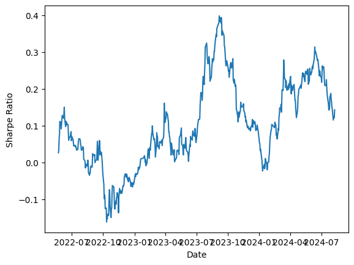

```python
from data import get_prices

def sharpe_ratio(asset, riskfree=0):
    return np.mean(asset - riskfree)/np.std(asset - riskfree)

start = '2022-01-01'
end = '2025-01-01'

closes = get_prices('FPT', start_date=start, end_date=end).FPT
returns = closes.pct_change()[1:] # Get the returns on the asset

running_sharpe = returns.rolling(90).apply(sharpe_ratio)

# Plot running Sharpe ratio up to 100 days before the end of the data set
_, ax1 = plt.subplots()
ax1.plot(running_sharpe[90:-100]);
plt.xlabel('Date')
plt.ylabel('Sharpe Ratio');
```

Tỷ lệ Sharpe có vẻ khá biến động, và rõ ràng là chỉ thể hiện nó dưới dạng một giá trị duy nhất sẽ không hữu ích nhiều cho việc dự đoán các giá trị trong tương lai. Thay vào đó, chúng ta có thể tính toán trung bình và độ lệch chuẩn của dữ liệu trên, và sau đó xem liệu điều này có giúp chúng ta dự đoán tỷ lệ Sharpe cho 100 ngày tới hay không.

```
Mean of running Sharpe ratio: 0.10157971821824213
std of running Sharpe ratio: 0.11828740780152286
```

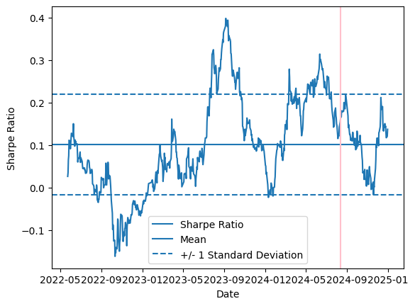

```python
# Compute the mean and std of the running Sharpe ratios up to 100 days before the end
mean_rs = np.mean(running_sharpe[90:-100])
std_rs = np.std(running_sharpe[90:-100])

# Plot running Sharpe ratio
_, ax2 = plt.subplots()
ax2.plot(running_sharpe[90:])

# Plot its mean and the +/- 1 standard deviation lines
ax2.axhline(mean_rs)
ax2.axhline(mean_rs + std_rs, linestyle='--')
ax2.axhline(mean_rs - std_rs, linestyle='--')

# Indicate where we computed the mean and standard deviations
# Everything after this is 'out of sample' which we are comparing with the estimated mean and std
ax2.axvline(returns.index[-100], color='pink');
plt.xlabel('Date')
plt.ylabel('Sharpe Ratio')
plt.legend(['Sharpe Ratio', 'Mean', '+/- 1 Standard Deviation'])

print('Mean of running Sharpe ratio:', mean_rs)
print('std of running Sharpe ratio:', std_rs)
```

Độ lệch chuẩn trong trường hợp này chứa khoảng một phần tư của khoảng giá trị, vì vậy dữ liệu này cực kỳ biến động. Khi xem xét điều này khi nhìn về phía trước, nó đã đưa ra dự đoán tốt hơn so với chỉ sử dụng giá trị trung bình, mặc dù chúng ta vẫn quan sát thấy dữ liệu lệch hơn một độ lệch chuẩn. Chúng ta cũng có thể tính toán giá trị trung bình động của tỷ lệ Sharpe để cố gắng theo dõi các xu hướng; nhưng trong trường hợp đó, chúng ta cũng nên nhớ đến độ lệch chuẩn.

## Ví dụ: Trung bình động

Giả sử bạn lấy trung bình với một khoảng thời gian nhìn lại; làm thế nào bạn có thể xác định sai số chuẩn trên ước lượng đó? Hãy bắt đầu với một ví dụ cho thấy trung bình động 90 ngày.

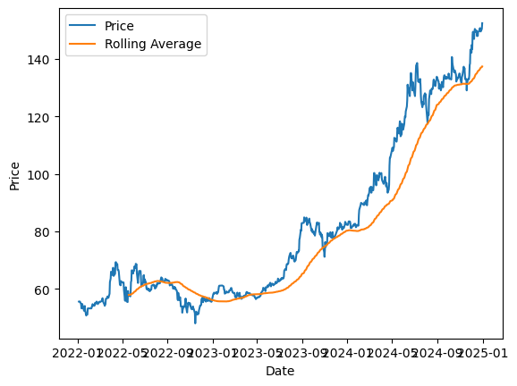

```python
# Compute the rolling mean for each day
mu = closes.rolling(window=90).mean()

# Plot pricing data
_, ax1 = plt.subplots()
ax1.plot(closes)
plt.ylabel('Price')
plt.xlabel('Date')

# Plot rolling mean
ax1.plot(mu);
plt.legend(['Price','Rolling Average']);
```

Biểu đồ này cho phép chúng ta thấy được sự không ổn định/lỗi chuẩn của trung bình, và giúp dự đoán sự biến đổi trong tương lai của dữ liệu. Chúng ta có thể định lượng sự biến đổi này bằng cách tính toán trung bình và độ lệch chuẩn của trung bình động.

```python
print('Mean of rolling mean:', np.mean(mu))
print('std of rolling mean:', np.std(mu))
```

```
Mean of rolling mean: 79.7637450059012
std of rolling mean: 25.926643258247587
```

Trên thực tế, độ lệch chuẩn, mà chúng ta sử dụng để định lượng sự biến đổi, chính nó cũng có tính biến đổi. Dưới đây, chúng tôi vẽ đồ thị độ lệch chuẩn động (cho khoảng thời gian 90 ngày) và tính *trung bình* và độ lệch chuẩn của *nó*.

```
Mean of rolling std: 5.155217989768159
std of rolling std: 3.1197820424647005
```

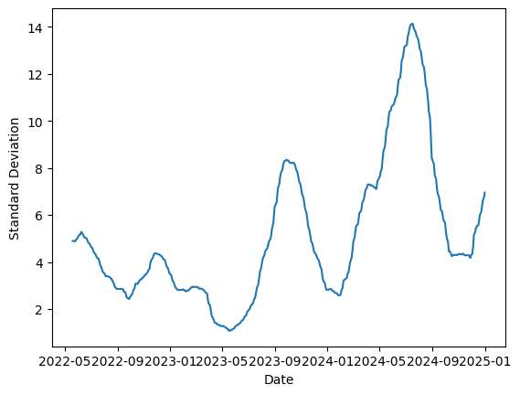

```python
# Compute rolling standard deviation
std = closes.rolling(window=90).std()

# Plot rolling std
_, ax2 = plt.subplots()
ax2.plot(std)
plt.ylabel('Standard Deviation')
plt.xlabel('Date')

print('Mean of rolling std:', np.mean(std))
print('std of rolling std:', np.std(std))
```

Để xem ý nghĩa của độ lệch chuẩn thay đổi này đối với tập dữ liệu của chúng ta, hãy vẽ lại dữ liệu cùng với các dải Bollinger: giá trị trung bình động, một độ lệch chuẩn động (của dữ liệu) ở trên giá trị trung bình và một độ lệch chuẩn ở dưới.

Lưu ý rằng mặc dù độ lệch chuẩn cung cấp cho chúng ta nhiều thông tin hơn về sự phân tán của dữ liệu, nhưng chúng ta không thể gán xác suất chính xác cho những kỳ vọng của mình về các quan sát trong tương lai mà không giả định một phân phối cụ thể cho quá trình cơ sở.

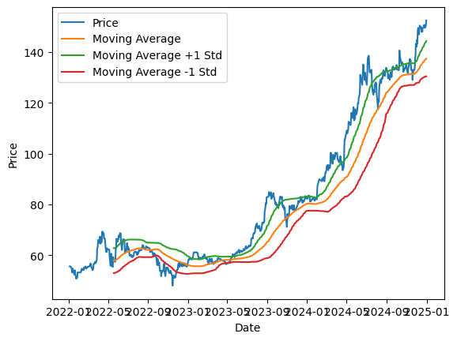

```python
# Plot original data
_, ax3 = plt.subplots()
ax3.plot(closes)

# Plot Bollinger bands
ax3.plot(mu)
ax3.plot(mu + std)
ax3.plot(mu - std);
plt.ylabel('Price')
plt.xlabel('Date')
plt.legend(['Price', 'Moving Average', 'Moving Average +1 Std', 'Moving Average -1 Std'])
```

## Kết luận

Mỗi khi chúng ta tính toán một tham số cho một bộ dữ liệu, chúng ta cũng nên tính toán độ biến động của nó. Nếu không, chúng ta không biết liệu các điểm dữ liệu mới có phù hợp với tham số này hay không. Một cách tốt để tính toán độ biến động là chia dữ liệu thành các tập con và ước lượng tham số từ từng tập, sau đó tìm độ biến thiên giữa các kết quả. Vẫn có thể có những yếu tố bên ngoài được đưa vào sau thời gian mẫu của chúng ta và mà chúng ta không thể dự đoán. Tuy nhiên, phân tích sự không ổn định và kiểm tra sai số chuẩn vẫn rất hữu ích để cho chúng ta biết mức độ không tin cậy của các ước lượng của mình.

*Lưu ý: Tài liệu này mang tính chất chia sẻ kiến thức khoa học dữ liệu. Các mã chứng khoán xuất hiện trong tài liệu chỉ mang tính chất minh hoạ, không khuyến nghị đầu tư. Chúng tôi không chịu trách nhiệm trước mọi rủi ro nào do sử dụng tài liệu này.*